# Bar Graphs

This is a brief tutorial on how to make bar graphs. It also provides a little information on how to stylize bar graphs to make them look better. There are a plethora of options to make a bar graph look like the visualization that you want it to. Lets dive in!

## Bar Graphs in R

For the R demonstration, you need to call the ‘tidyverse’ package. Instructions to install and call the ‘tidyverse’ package are in the code chunk below

```r
if (!require("pacman")) install.packages("pacman")
pacman::p_load(tidyverse)
```

This tutorial will use a dataset that already exists in R, so no need to load any new data into your environment. The dataset we will use is called ‘Starwars’, which uses data collected from the Starwars Universe. The ‘tidyverse’ package uses ‘ggplot2’ to construct bar graphs. For our first example, lets look at species appearences in starwars movies. Follow along below!

- First for our graph, we need write a line that calls ggplot2. However we just use ‘ggplot’ to do so. Note the + after ggplot(). This + ties the subsequent lines together to form the graph. A common error when making any type of graph in ggplot() is to forget these + symbols at the end of a code line, so just remember to use them!
- There are a couple of steps to construct a bar graph. First we need to specify the data we want to visulaize. We are making a bar graph, so we will use geom_bar. Since we want to use the ‘starwars’ dataset, we set data = starwars. Remember the comma after this otherwise an error will appear.
- Next we want to tell ggplot what we want to map. We use the mapping function to do this. We set mapping to the aesthetic function. (mapping = aes(x = species)) Within the aes function we want to specify what we want our x value to be, in this case species. Copy the code below to make your first bar graph!

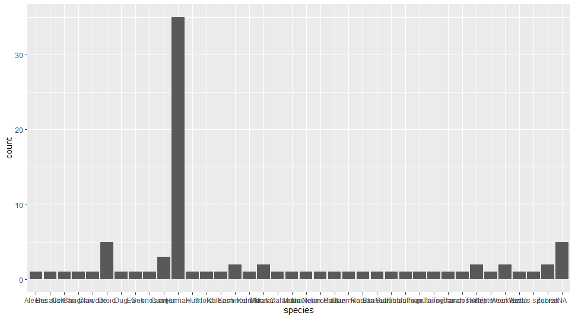

r_bar_graph_1

```r
 ggplot() +
    geom_bar(data = starwars, mapping = aes(x = species))
```

As you can see there are some issues, we can’t tell what the individual species are on the x axis. We also might want to give our graph a title, maybe give it some color, etc. How do we do this? By adding additional functions to our graph!

ggplot(data = starwars) + geom_bar( mapping = aes(x = species), color = “black”, fill = “blue”) + labs(x = “Species”, y = “Total”, title = “Character Appearences in Movies by Species”) + theme(axis.text.x = element_text(angle = 45, hjust = 1))

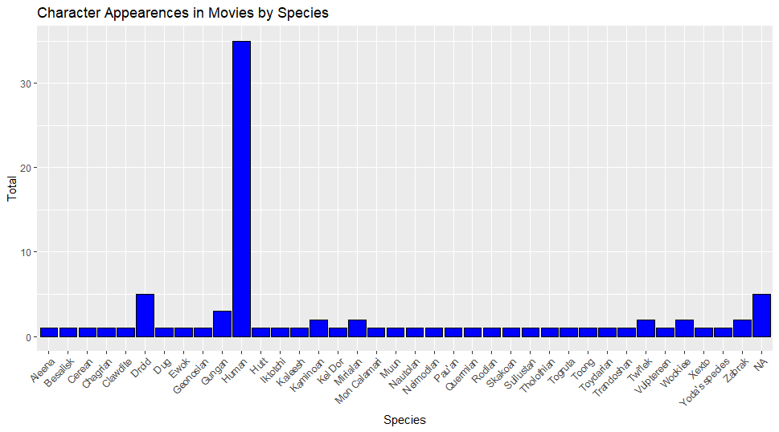

r_bar_graph_2

This graph looks much more interpretable to me, though appearences are subjective. Let’s look at what we did. First there are two additional parts to our mapping function, color and fill. The “color =” provides an outline color to the bars on the graph, while “fill =” provides the color within the bars. The x and y axis have been renamed, and the graph has been given a title. This was done using the labs() function in R. This function has additional options as well which you should explore. Finally we come to the theme() function in ggplot2. theme() has many options to customize any type of graph in R. For this basic tutorial, the x values (species) have been rotated so that they are legible compared to our first graph. Congratualtions, you have made your first bar graph in R!

There is a similar gg_plot() function in R called geom_col. In geom_col, you can specify what you want the y axis to be, whereas geom_bar is only a count. Want more information on how to customize your graph? The Hadley Wickam book called [R for Data Science](https://r4ds.had.co.nz/) is a fantastic place to start, best of all it’s free! Websites such as Stack Overflow are also good places to look for answers to whatever questions you might have.

## Bar Graphs in Stata

Stata, like R, also has pre-installed datasets available for use. To find them, click on ‘file’, then click on ‘Example Datasets’ which will open up a new window. Under ‘Description’ click on the link for ‘Example datasets installed with Stata’ which will bring up a list of datasets to use for examples. For the purposes of this demonstration we will use the ‘bplong.dta’ option. To load it into stata, click ‘use’ and it will appear in Stata.

This is fictionalized blood pressure data. In your variables column you should have five variables (patient, sex, agegrp, when, bp). Let’s make a bar chart that looks at the patients within our dataset by gender and age. To make a bar chart type into your stata command console:

### graph bar, over(sex) over(agegrp)

and the following output should appear in another window.

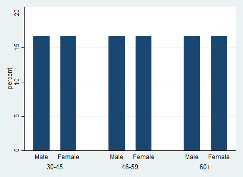

bar_graph_1.png

Congratulations, you’ve made your first bar chart in Stata! We can now visually see the make-up of our dataset by gender and age. We might want to change the axis labels or give this a title. To do so type the following in your command window:

### graph bar, over(sex) over(agegrp) title(Our Graph) ytitle(Percent)

and the following graph shoud appear

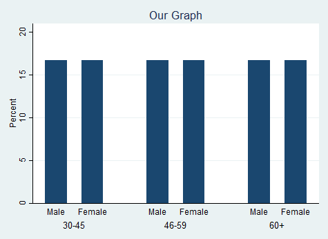

bar_graph_2

Notice we gave our graph a title and capitalized the y axis. Lets add some color next. To do so type

### graph bar, over(sex) over(agegrp) title(Our Graph) ytitle(Percent) bar(1, fcolor(red)) bar(2, fcolor(blue))

and the following graph should appear

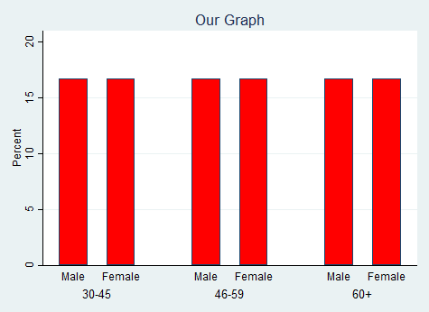

bar_graph_3

Our bars are now red with a blue outline. Pretty neat! There are many sources of Stata help on the internet and many different way to customize your bar graphs. There is an official Stata support page that can answer queries regarding Stata.